სმკმ: მეცხრე შეხვედრა

# სოციალურ მეცნიერებათა კვლევის მეთოდები

დავით სიჭინავა  
5 დეკემბერი, 2019 წ.

მეცხრე შეხვედრა

### დღევანდელი შეხვედრის გეგმა

- ლექცია: კითხვარი, გაზომვა და სკალები
- სემინარი

### საბოლოო დავალება: კვლევის დიზაინის შემუშავება

- შესავალი და კონცეფცია
- ლიტერატურის მიმოხილვა
- კვლევის ინსტრუმენტი

*ინდივიდუალური დავალება*

### გაზომვა: ცვლადის ტიპები

- თვისებრივი:
  - სახელდების (ნომინალური)
- რაოდენობრივი:
  - რიგის (ორდინალური)
  - ინტერვალის
  - შეფარდების

### სახელდების (ნომინალური) სკალა

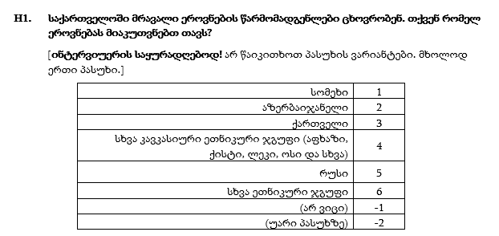

### რიგის (ორდინალური) სკალა

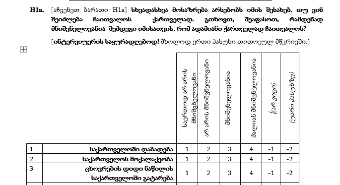

### ინტერვალის და შეფარდების სკალა

- აბსოლუტური ნულის არსებობა
- სკალის ელემენტებს შორის მანძილის ინტერპრეტაცია შესაძლებელია

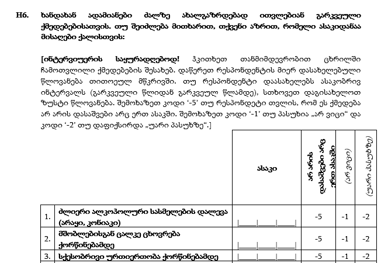

### ვალიდობა

- შინაარსის
  - ინსტრუმენტის შესაბამისობა ცვლადის თავისებურებებთან - რამდენად წარმოადგენს კითხვა ან კითხვები გასაზომ მახასიათებლებს
- ემპირიული
  - ურთიერთკავშირი ნაწინასწარმეტყველებ და მიღებულ შედეგებს შორის
- კონსტრუქტორული
  - ურთიერთკავშირი თეორიულ სისტემასთან

### სანდოობა

- განმეორებითი (ტესტირება/რეტესტირება) შემოწმება
  - ინსტრუმენტის შემოწმება რამდენჯერმე ერთსა და იმავე ჯგუფთან
- პარალელური ფორმები
  - ორი პარალელური ინსტრუმენტის გამოყენება ერთსა და იმავე ჯგუფთან
- გახლეჩვის მეთოდი
  - ერთი ინსტრუმენტის შუაზე გაყოფა და ერთსა და იმავე ჯგუფთან შემოწმება

### სკალები და ინდექსები

- ორი ან მეტი ინდიკატორის კომბინირება
- მაგ.სამომხმარებლო ფასების ინდექსი:

\( I = \frac{\sum p_{i}q_{0}}{\sum p_{0}q_{0}} \)

### სკალები და ინდექსები

- მაგ.შინამეურნეობის ეკონომიკური მდგომარეობის ინდექსი:
  - ოჯახში არსებული სხვადასხვა ნივთების რაოდენობა

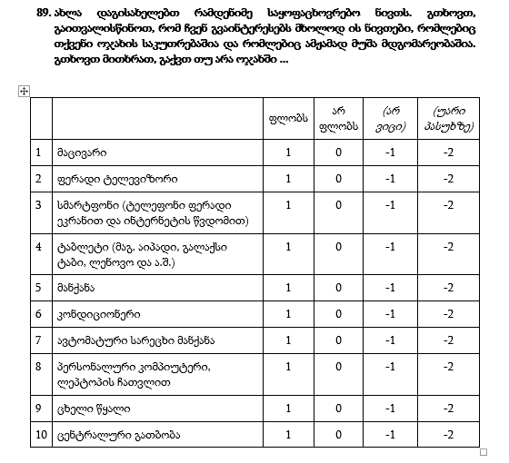

### თურსტოუნის სკალა

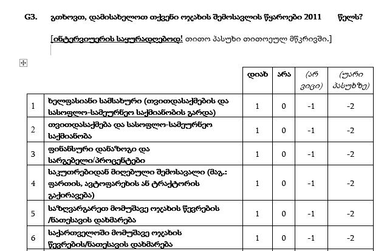

### თურსტოუნის სკალა

- ჩამოწერეთ შესაძლო დებულებები,
- შეაფასეთ დებულებები 1-11 სკალაზე, კონცეფციასთან შესაბამისობის მხრივ,
- ამოაგდეთ ის დებულებები, რომლებსაც ყველა შეუსაბამოდ თვლის,
- კითხვის პასუხებად აიღეთ ,,დიახ/არა"

### ლიკერტის სკალა

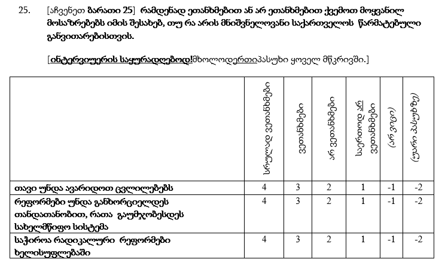

### ლიკერტის სკალა

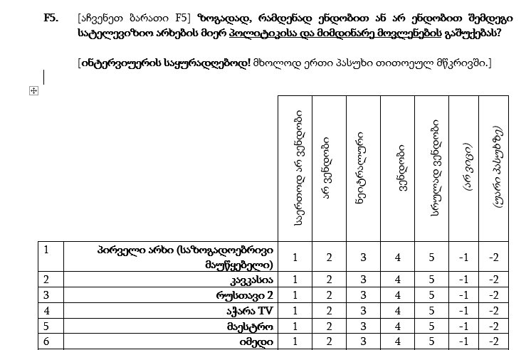

### ლიკერტის სკალა

- სკალის შესაძლო პუნქტების შედგენა
- პუნქტების მთლიანი და საშუალო მაჩვენებლების გამოთვლა
- პუნქტების დისკრიმინაციული ძალის გამოთვლა
- სკალის საბოლოო დებულებების შერჩევა
- დებულებათა სანდოობის შემოწმება

### კრონბახის ალფა

- დებულებების ერთობლიობის შინაგანი თანხმობის შეფასება

### გუტმანის სკალა (Guttman scale)

| დებულება | შეფასება |
| --- | --- |
| მე მიყვარს სეირნობა |  |
| მე მიყვარს პარკში სეირნობა |  |
| მე მიყვარს ვაკის პარკში სეირნობა |  |
| მე მიყვარს მზიან ამინდში ვაკის პარკში სეირნობა |  |

### გუტმანის სკალა

- სამიზნე პოპულაციაში ნამდვილად უნდა არსებობდეს დამოკიდებულება (ატტიტუდი) საკვლევი ობიექტის მიმართ
- საჭიროა შესაბამისი დებულებების პოვნა, რომელიც ზუსტად ასახავს ამ ობიექტის კომპონენტებს
- ყველა დებულება *თანმიმდევრულად* უნდა ზომავდეს ამ ობიექტის ცალკეულ კომპონენტს

### სხვა სკალები

- საწინააღმდეგო დებულებათა რომბი,
- ბოგარდუსის სოციალური დისტანციის სკალა,
- ოზგუდის სემანტიკური დიფერენციალის სკალა

### კითხვარი

- ფაქტობრივი კითხვები

### კითხვარი: ფაქტობრივი კითხვები

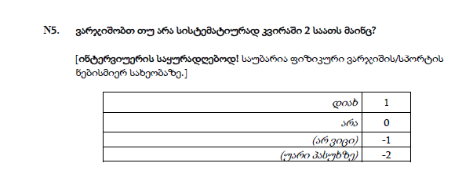

### კითხვარი

- სუბიექტური გამოცდილება

### კითხვარი

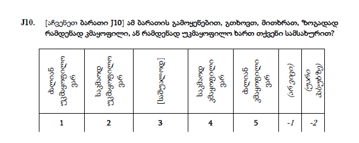

### კითხვარი (წულაძე, 2004)

- ატრიბუტები
- ქცევები
- განწყობები
- რწმენები

### კითხვარი (წულაძე, 2004)

- ნეიტრალური ქცევითი შეკითხვები
- ქცევითი შეკითხვები, რომლებზეც პასუხის გაცემა რესპონდენტს აფრთხობს
- დამოკიდებულების/განწყობის გასაზომი შეკითხვები
- ცოდნის შესაფასებელი შეკითხვები
- შესრულების შესაფასებელი შეკითხვები
- ფსიქოგრაფიული შეკითხვები
- დემოგრაფიული შეკითხვები

### კითხვის ფორმები

- ღია
- დახურული

### ღია თუ დახურული კითხვარი?

- მიზნები
- ინფორმირებულობის დონე
- თემის გააზრება
- მოტივაცია და შინაარსობრივი მზადყოფნა

### დახურული კითხვის ფორმები

- შეფასების სკალა
- რანჟირების სკალა
- სემანტიკური დიფერენციალი
- საკონტროლო სია

### შემთხვევითი კითხვები (გადასვლები)

- მოსახლეობის *სპეციალური* ჯგუფები

### კითხვების თანმიმდევრობა

- ე.წ. ძაბრისებური თანმიმდევრობა
- ამობრუნებული ძაბრისებური თანმიმდევრობა

### კითხვარის შედგენის პრინციპები

- რესპონდენტთან შესაბამისობა
- ენა და ჟარგონი
- მგრძნობელობა
- პრესტიჟი
- მიმართულების მიმცემი კითხვები
- ჰიპოთეტური კითხვები
- ორმაგი შეკითხვები
- დროის შუალედების აღმწერი კითხვები
- გადამფარავი კატეგორიები

### ფორმატი

- თავფურცელი
  - ნუმერაცია
  - მიმართვის ტექსტი
  - რესპონდენტის შერჩევა
- სექციები
  - თემატურობა!
- ინსტრუქციები
  - ბარათები
- ინტერვიუერის შეფასება

### კითხვის ფორმატი, ფორმულირება, თანმიმდევრობა და პასუხების განაწილება

[figure not shown]

### კითხვის ფორმატი, ფორმულირება და პასუხების განაწილება

[figure not shown]

### კითხვის ფორმატი, ფორმულირება და პასუხების განაწილება

[figure not shown]

### დავალება მომდევნო ლექციისთვის:

- მე თითოეულ თქვენგანს მივცემ ქართულენოვან კითხვარს და შესაბამის დოკუმენტებს
- ერთგვერდიან ესეში (რომლის სტრუქტურასაც აგიტვირთავთ), უნდა შეაფასოთ კითხვარის დადებითი და უარყოფითი მხარეები, ასევე - კითხვების ტიპოლოგია.
- დავალება წინას მსგავსად, ლინკზე უნდა ატვირთოთ
- სრული აღწერისთვის, ხვალ დილიდან შეამოწმეთ კურსის ვებსაიტი